# Análise 1: Os dados são confiáveis ?

## A proposta dessa anélise e verificar a veracidade desses dados , isto é ,dado uma População , ao examinarmos um conjunto de amostras , a maioria delas vai seguir o mesmo padrão ? Ou seja, já sabendo os possíveis resultados futuros da População essas essas amostras vão obter os mesmos resultados ? Será que os resultados estarão "bem distríbuidos" de forma uniforme ? Dessa forma poderemos garantir a confiabilidade dos dados e que eles seguem um padrão praticamente uniforme.

```python
import pandas as pd
import matplotlib.pyplot as plt
import numpy as np
```

### Para realização dessas análise, usamos como base a tabela "service_order" disponivel no banco de dados.

```python
ocurrencies = pd.read_csv("service_order.csv")
```

```python
ocurrencies.head()
```

|  | id | customer_id | status | total_amount_products | total_amount_services | discount | total_amount | received_at | realized_at | delivery_at | equipments_description | defects_description | technical_report | warranty | created_at |
| --- | --- | --- | --- | --- | --- | --- | --- | --- | --- | --- | --- | --- | --- | --- | --- |
| 0 | 1 | 2 | 5 | 239.50 | 52.0 | 0.0 | 291.50 | 1.549294e+12 | 1549293585069 | 1.549553e+12 | NaN | vazamento reservatório principal de envaze | colar com p.u. 40 internamente colado duas vez... | NaN | 1549293585069 |
| 1 | 2 | 1 | 5 | 0.00 | 104.0 | 0.0 | 104.00 | 1.549294e+12 | 1549293638718 | 1.549553e+12 | NaN | NaN | troca de rolamento e ajuste facão de corte | NaN | 1549293638718 |
| 2 | 3 | 5 | 5 | 1301.00 | 208.0 | 0.0 | 1509.00 | 1.551111e+12 | 1551197680533 | 1.551198e+12 | NaN | NaN | NaN | NaN | 1551197680533 |
| 3 | 4 | 7 | 5 | 360.00 | 52.0 | 0.0 | 412.00 | 1.551198e+12 | 1551284495126 | 1.551284e+12 | NaN | NaN | NaN | NaN | 1551284495126 |
| 4 | 5 | 8 | 5 | 5.51 | 13.0 | 0.0 | 18.51 | 1.551350e+12 | 1551349816735 | 1.551350e+12 | NaN | torneira com vazamento | trocar torneira | NaN | 1551349816735 |

```python
ocurrencies.shape
```

```
(570, 15)
```

```python
ocurrencies.describe()
```

|  | id | customer_id | status | total_amount_products | total_amount_services | discount | total_amount | received_at | realized_at | delivery_at | created_at |
| --- | --- | --- | --- | --- | --- | --- | --- | --- | --- | --- | --- |
| count | 570.000000 | 570.000000 | 570.000000 | 570.000000 | 570.000000 | 570.0 | 570.000000 | 5.690000e+02 | 5.700000e+02 | 4.640000e+02 | 5.700000e+02 |
| mean | 293.157895 | 23.035088 | 4.445614 | 12.317105 | 7.075860 | 0.0 | 19.392965 | 1.603006e+12 | 1.603598e+12 | 1.604791e+12 | 1.603620e+12 |
| std | 166.363154 | 20.819304 | 1.479095 | 135.295048 | 40.892596 | 0.0 | 154.023469 | 1.658671e+10 | 1.641249e+10 | 1.594864e+10 | 1.642506e+10 |
| min | 1.000000 | 1.000000 | 0.000000 | 0.000000 | 0.000000 | 0.0 | 0.000000 | 1.549294e+12 | 1.549294e+12 | 1.549553e+12 | 1.549294e+12 |
| 25% | 149.250000 | 5.000000 | 5.000000 | 0.000000 | 0.000000 | 0.0 | 0.000000 | 1.599230e+12 | 1.600273e+12 | 1.603710e+12 | 1.600273e+12 |
| 50% | 294.500000 | 19.000000 | 5.000000 | 0.000000 | 0.000000 | 0.0 | 0.000000 | 1.606305e+12 | 1.606743e+12 | 1.607368e+12 | 1.606743e+12 |
| 75% | 436.750000 | 29.750000 | 5.000000 | 0.000000 | 0.000000 | 0.0 | 0.000000 | 1.614687e+12 | 1.614711e+12 | 1.615215e+12 | 1.614712e+12 |
| max | 579.000000 | 92.000000 | 5.000000 | 2765.000000 | 476.000000 | 0.0 | 2869.000000 | 1.627061e+12 | 1.627059e+12 | 1.627064e+12 | 1.627059e+12 |

```python
colunas_selecionadas=["id","created_at"]
```

```python
dados=ocurrencies.filter(items=colunas_selecionadas)
```

```python
dados
```

|  | id | created_at |
| --- | --- | --- |
| 0 | 1 | 1549293585069 |
| 1 | 2 | 1549293638718 |
| 2 | 3 | 1551197680533 |
| 3 | 4 | 1551284495126 |
| 4 | 5 | 1551349816735 |
| ... | ... | ... |
| 565 | 575 | 1627047225218 |
| 566 | 576 | 1627054162307 |
| 567 | 577 | 1627054823453 |
| 568 | 578 | 1627055240494 |
| 569 | 579 | 1627059154434 |

570 rows × 2 columns

### A partir dos dados fornecidos pela tabela, vamos fazer uma analise das Ocorrências dos serviços , para isso vamos associar a colunas: "id" e "created_at".

### Para uma mais detalhista vamos recorrer ao uso de recursos matemáticos e gráficos

```python
#cálculo da Margem de Erro:
std=166.363154
count=570.000000
Margem_de_Erro=(1.96*(std))/(count**(0.5))
```

```python
Margem_de_Erro
```

```
13.65764402073211
```

```python
#porcentagem da margem de erro
(Margem_de_Erro/count)*100
```

```
2.3960778983740547
```

### A Margem de Erro Encontrada foi de 2,39% que bem baixa, um bom indicar para garantir que confiança dos dados

## Recursos gráficos

```
array([[<AxesSubplot:title={'center':'created_at'}>]], dtype=object)
```

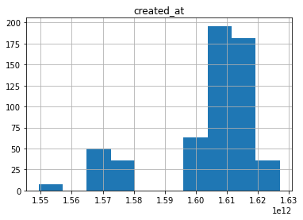

```python
dados.hist("created_at")
```

### A partir desse historgrama podemos visualizar que as entradas ocorrência foram aumentando a medida que os serviços foram pedidos ,a maior quantidade de entradas foi menor que 200.

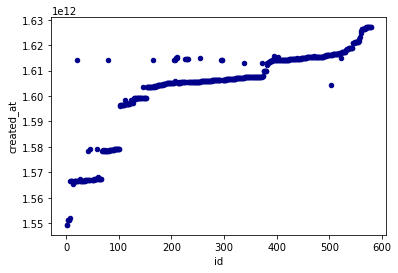

```python
ocurrencies.plot.scatter(x = "id",
                         y = "created_at",
                         c = "DarkBlue")
```

```python
occu=["id","created_at"]
```

### Note que : embora exsitem pontos fora da curva(outlliers) o gráfico se comporta de forma "constante" , demonstrando que exitem poucos valores que foguem do padrão.

```python
def plot_boxplot(df,ft):
    df.boxplot(column=[ft])
    plt.grid(False)
```

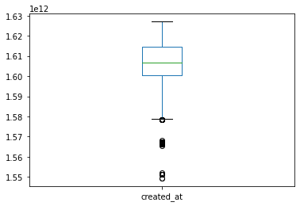

```python
plot_boxplot(ocurrencies,"created_at")
```

### Usamos um Boxplot afim de determinar um intervalo de confiança, e se ha invariántes.

.

### Como podemos ver , a grande maioria dos dados se encontra dentro do intervalo de confiança

## Executando uma pequena limpeza no gráfico

```python
def outliers(df,ft):
    q1= df[ft].quantile(.25)
    q3= df[ft].quantile(.75)
    print("Q1: {}, Q3: {}".format(q1, q3))
    iqr= q3-q1

    lower_bound= q1-(1.5*iqr)
    upper_bound= q3+(1.5*iqr)

    filtro = (df[ft] < lower_bound) | (df[ft] > upper_bound)
    ls = df[filtro]
    print(ls[ft])
    return list(ls[ft])
```

```python
index_list = outliers(ocurrencies, "created_at")
```

```
Q1: 1600273241909.75, Q3: 1614711843771.5
0     1549293585069
1     1549293638718
2     1551197680533
3     1551284495126
4     1551349816735
          ...
76    1578573756529
77    1578599865705
78    1578599963486
79    1578600170707
80    1578600355154
Name: created_at, Length: 77, dtype: int64
```

```python
from numpy import mean, std, percentile
def reject_outliers(data):
    q25, q75 = percentile(data, 25), percentile(data, 75)
    iqr = q75 - q25
    cut_off = iqr * 1.5
    lower, upper = q25 - cut_off, q75 + cut_off
    return [x for x in list(data) if x > lower and x < upper]
```

```python
rate = 20
not_outliers = []
for i in range(int(len(ocurrencies)/rate)):
    l = list(ocurrencies['created_at'].iloc[rate*i:rate*(i+1)])
    not_outliers.extend(reject_outliers(l))
```

```python
print(len(ocurrencies['created_at']), len(not_outliers))
```

```
570 509
```

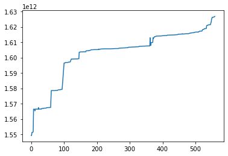

```python
ocurrencies['created_at'].apply(lambda x: x if x in not_outliers else np.NaN).dropna().plot.line()
```

# conclusão

### Como podemos ver, já no gráfico já limpos e a partir dos resultados encontrados .Embora existam alguns "saltos" entre os intervalos , em sua grande maioria , a curva aparenta se comportar de forma uniforme e bem comportados, além de encontrar um valor de erro relativamente pequeno , para um grau de confiaça de 95%. Os dados são confiáveis